# Module 2 Task 2

# 1.Libraries

```python
# SQL
from sqlalchemy import create_engine
import pymysql

# DS Bsics
import numpy as np
import pandas as pd
from pandas_profiling import ProfileReport
import matplotlib.pyplot as plt
import seaborn as sns

# corrplot from heatmapz https://pypi.org/project/heatmapz/
from heatmap import corrplot
```

# 2.Download Data

remove the # to execute the cells

```python
#db_connection_str = 'mysql+pymysql://deepanalytics:Sqltask1234!@34.73.222.197/deepanalytics'
#db_connection = create_engine(db_connection_str)
#df = pd.read_sql('SELECT * FROM credit', con=db_connection)
### write to csv
#df.to_csv('dataset_M2_Original.csv', index=False) #index=False
#df.head()
```

# 3.EDA

## 3.1 Data Pre-processing

### Removing some annoying rows

Let's start reading data and printing the head()

```python
# import data
df = pd.read_csv('dataset_M2_Original.csv')
df.head()
```

|  | MyUnknownColumn | X1 | X2 | X3 | X4 | X5 | X6 | X7 | X8 | X9 | ... | X15 | X16 | X17 | X18 | X19 | X20 | X21 | X22 | X23 | Y |
| --- | --- | --- | --- | --- | --- | --- | --- | --- | --- | --- | --- | --- | --- | --- | --- | --- | --- | --- | --- | --- | --- |
| 0 | ID | LIMIT_BAL | SEX | EDUCATION | MARRIAGE | AGE | PAY_0 | PAY_2 | PAY_3 | PAY_4 | ... | BILL_AMT4 | BILL_AMT5 | BILL_AMT6 | PAY_AMT1 | PAY_AMT2 | PAY_AMT3 | PAY_AMT4 | PAY_AMT5 | PAY_AMT6 | default payment next month |
| 1 | 1 | 20000 | female | university | 1 | 24 | 2 | 2 | -1 | -1 | ... | 0 | 0 | 0 | 0 | 689 | 0 | 0 | 0 | 0 | default |
| 2 | 2 | 120000 | female | university | 2 | 26 | -1 | 2 | 0 | 0 | ... | 3272 | 3455 | 3261 | 0 | 1000 | 1000 | 1000 | 0 | 2000 | default |
| 3 | 3 | 90000 | female | university | 2 | 34 | 0 | 0 | 0 | 0 | ... | 14331 | 14948 | 15549 | 1518 | 1500 | 1000 | 1000 | 1000 | 5000 | not default |
| 4 | 4 | 50000 | female | university | 1 | 37 | 0 | 0 | 0 | 0 | ... | 28314 | 28959 | 29547 | 2000 | 2019 | 1200 | 1100 | 1069 | 1000 | not default |

5 rows × 25 columns

Nice, now take a look to the categorical variables.

```python
df[['X2', 'X3', 'X4']].describe()
```

|  | X2 | X3 | X4 |
| --- | --- | --- | --- |
| count | 30204 | 30204 | 30204 |
| unique | 4 | 6 | 6 |
| top | female | university | 2 |
| freq | 18217 | 14107 | 16088 |

There is something strange in this DF. 4 values in the column 'X2' (SEX). Let's print the unique values it has:

```python
df.X2.unique()
```

```
array(['SEX', 'female', 'male', 'X2'], dtype=object)
```

the words 'SEX' and 'X2' shouldn't be there.. Let's see which rows contains those words, to perform that we can use .loc method

```python
df.loc[df['X2']=='SEX']
```

|  | MyUnknownColumn | X1 | X2 | X3 | X4 | X5 | X6 | X7 | X8 | X9 | ... | X15 | X16 | X17 | X18 | X19 | X20 | X21 | X22 | X23 | Y |
| --- | --- | --- | --- | --- | --- | --- | --- | --- | --- | --- | --- | --- | --- | --- | --- | --- | --- | --- | --- | --- | --- |
| 0 | ID | LIMIT_BAL | SEX | EDUCATION | MARRIAGE | AGE | PAY_0 | PAY_2 | PAY_3 | PAY_4 | ... | BILL_AMT4 | BILL_AMT5 | BILL_AMT6 | PAY_AMT1 | PAY_AMT2 | PAY_AMT3 | PAY_AMT4 | PAY_AMT5 | PAY_AMT6 | default payment next month |
| 203 | ID | LIMIT_BAL | SEX | EDUCATION | MARRIAGE | AGE | PAY_0 | PAY_2 | PAY_3 | PAY_4 | ... | BILL_AMT4 | BILL_AMT5 | BILL_AMT6 | PAY_AMT1 | PAY_AMT2 | PAY_AMT3 | PAY_AMT4 | PAY_AMT5 | PAY_AMT6 | default payment next month |

2 rows × 25 columns

well.. rows 0 and 203 contains strange things, that are, basically, no useful data.

We have to remove them, and we can do that in different ways.

```python
# in this case we're performing a copy of rows that NOT contain the word 'X2'
df = df[df.X2 != 'X2']
# and let's take a look to the output
df.X2.unique()
```

```
array(['SEX', 'female', 'male'], dtype=object)
```

worked nice, repeat with 'SEX'

```python
df = df[df.X2 != 'SEX']
df.X2.unique()
```

```
array(['female', 'male'], dtype=object)
```

Great now, at least X2, seems clean. let's see if we have to repeat the process with X3 and X4...

```python
print(df.X3.unique())
print(df.X4.unique())
```

```
['university' 'graduate school' 'high school' 'other']
['1' '2' '3' '0']
```

```python
df[['X2', 'X3', 'X4']].describe()
```

|  | X2 | X3 | X4 |
| --- | --- | --- | --- |
| count | 30201 | 30201 | 30201 |
| unique | 2 | 4 | 4 |
| top | female | university | 2 |
| freq | 18217 | 14107 | 16088 |

There are no strange values and now the description and amount of values matches the documentation.

### Rename columns

Just to make the DF readable, change the titles of the columns

```python
df.rename(columns = {'MyUnknownColumn':'ID',
                     'X1':'LIMIT_BAL',
                     'X2':'SEX',
                     'X3':'EDU',
                     'X4':'MAR',
                     'X5':'AGE',
                     'X6':'PAY_0',
                     'X7':'PAY_2',
                     'X8':'PAY_3',
                     'X9':'PAY_4',
                     'X10':'PAY_5',
                     'X11':'PAY_6',
                     'X12':'BILL_AMT1',
                     'X13':'BILL_AMT2',
                     'X14':'BILL_AMT3',
                     'X15':'BILL_AMT4',
                     'X16':'BILL_AMT5',
                     'X17':'BILL_AMT6',
                     'X18':'PAY_AMT1',
                     'X19':'PAY_AMT2',
                     'X20':'PAY_AMT3',
                     'X21':'PAY_AMT4',
                     'X22':'PAY_AMT5' ,
                     'X23':'PAY_AMT6',

                              }, inplace = True)
```

```python
# print a random sample of the dataset to verify
df.sample(4)
```

|  | ID | LIMIT_BAL | SEX | EDU | MAR | AGE | PAY_0 | PAY_2 | PAY_3 | PAY_4 | ... | BILL_AMT4 | BILL_AMT5 | BILL_AMT6 | PAY_AMT1 | PAY_AMT2 | PAY_AMT3 | PAY_AMT4 | PAY_AMT5 | PAY_AMT6 | Y |
| --- | --- | --- | --- | --- | --- | --- | --- | --- | --- | --- | --- | --- | --- | --- | --- | --- | --- | --- | --- | --- | --- |
| 24172 | 23969 | 120000 | male | university | 2 | 25 | 1 | 2 | 2 | 2 | ... | 52206 | 10325 | 8992 | 2200 | 1828 | 500 | 0 | 500 | 1000 | default |
| 13623 | 13420 | 20000 | male | university | 1 | 44 | 0 | 0 | 0 | 0 | ... | 18654 | 19584 | 19390 | 1309 | 1285 | 657 | 2000 | 388 | 390 | default |
| 14728 | 14525 | 380000 | female | graduate school | 2 | 31 | -2 | -2 | -2 | -1 | ... | 196050 | 202129 | 295891 | 276 | 0 | 202129 | 9500 | 98500 | 17000 | not default |
| 5164 | 4961 | 210000 | female | graduate school | 1 | 34 | 0 | 0 | 0 | 0 | ... | 116351 | 95854 | 91173 | 9510 | 7000 | 10079 | 4500 | 3532 | 3500 | not default |

4 rows × 25 columns

### DTypes Analysis

If we run a df.dtypes we get all columns as "object". This happens when mixed dtypes or just strings. So let's analyze each column and change it's type to a suitable one.

#### Verification of dtypes

```python
df.dtypes
```

```
ID           object
LIMIT_BAL    object
SEX          object
EDU          object
MAR          object
AGE          object
PAY_0        object
PAY_2        object
PAY_3        object
PAY_4        object
PAY_5        object
PAY_6        object
BILL_AMT1    object
BILL_AMT2    object
BILL_AMT3    object
BILL_AMT4    object
BILL_AMT5    object
BILL_AMT6    object
PAY_AMT1     object
PAY_AMT2     object
PAY_AMT3     object
PAY_AMT4     object
PAY_AMT5     object
PAY_AMT6     object
Y            object
dtype: object
```

```python
ages = list(df.AGE)
type(ages[0])
```

```
str
```

For example, AGE is stored as strings, and should be integer.

#### change Dtypes

Let use a dictionary method to convert types of each column.

```python
convert_dict = {'ID':int,
                'LIMIT_BAL':float,
                'SEX':str,
                'EDU':str,
                'MAR':int,
                'AGE':int,
                'PAY_0':float,
                'PAY_2':float,
                'PAY_3':float,
                'PAY_4':float,
                'PAY_5':float,
                'PAY_6':float,
                'BILL_AMT1':float,
                'BILL_AMT2':float,
                'BILL_AMT3':float,
                'BILL_AMT4':float,
                'BILL_AMT5':float,
                'BILL_AMT6':float,
                'PAY_AMT1':float,
                'PAY_AMT2':float,
                'PAY_AMT3':float,
                'PAY_AMT4':float,
                'PAY_AMT5' :float,
                'PAY_AMT6':float,
                'Y':str
                }
df = df.astype(convert_dict)
df.dtypes
```

```
ID             int64
LIMIT_BAL    float64
SEX           object
EDU           object
MAR            int64
AGE            int64
PAY_0        float64
PAY_2        float64
PAY_3        float64
PAY_4        float64
PAY_5        float64
PAY_6        float64
BILL_AMT1    float64
BILL_AMT2    float64
BILL_AMT3    float64
BILL_AMT4    float64
BILL_AMT5    float64
BILL_AMT6    float64
PAY_AMT1     float64
PAY_AMT2     float64
PAY_AMT3     float64
PAY_AMT4     float64
PAY_AMT5     float64
PAY_AMT6     float64
Y             object
dtype: object
```

**CONCLUSION** now all types are correct!!. I used float to the datatype for LIMIT_BAL, PAY_x, BILL_ATMx, and PAY_ATMx because: 1) I didn't check all the values, but I didn't see any float, anyway 2) somebody could pay some XX dollars with YY cents. So I assumed that those values should be stored as floats. Also I know that this decision could increase the processing time of the next steps. If necessary, we can change them to integers.

### Relabel Marriage

The only categorical variable that still encoded is MAR (marital status), so let's convert numbers into legible words.

```python
marital_status = {
    0: 'others',
    1: 'married',
    2: 'single',
    3: 'divorce'

 }
df['MAR'] = df['MAR'].replace(marital_status)
```

## 3.2 Data Cleaning

First at all, let's take a look to the general situation.

```python
df.info()
```

```
<class 'pandas.core.frame.DataFrame'>
Int64Index: 30201 entries, 1 to 30203
Data columns (total 25 columns):
 #   Column     Non-Null Count  Dtype
---  ------     --------------  -----
 0   ID         30201 non-null  int64
 1   LIMIT_BAL  30201 non-null  float64
 2   SEX        30201 non-null  object
 3   EDU        30201 non-null  object
 4   MAR        30201 non-null  object
 5   AGE        30201 non-null  int64
 6   PAY_0      30201 non-null  float64
 7   PAY_2      30201 non-null  float64
 8   PAY_3      30201 non-null  float64
 9   PAY_4      30201 non-null  float64
```

[output cut: 17 more lines]

no nulls values. Now, lest's drop the duplicated rows.

```python
df = df.drop_duplicates()
df.info()
```

```
<class 'pandas.core.frame.DataFrame'>
Int64Index: 30000 entries, 1 to 30203
Data columns (total 25 columns):
 #   Column     Non-Null Count  Dtype
---  ------     --------------  -----
 0   ID         30000 non-null  int64
 1   LIMIT_BAL  30000 non-null  float64
 2   SEX        30000 non-null  object
 3   EDU        30000 non-null  object
 4   MAR        30000 non-null  object
 5   AGE        30000 non-null  int64
 6   PAY_0      30000 non-null  float64
 7   PAY_2      30000 non-null  float64
 8   PAY_3      30000 non-null  float64
 9   PAY_4      30000 non-null  float64
```

[output cut: 17 more lines]

we deleted 201 duplicate lines.

## 3.3 Dealing with non-numerical data (One-Hot Encoding)

```python
df.dtypes
```

```
ID             int64
LIMIT_BAL    float64
SEX           object
EDU           object
MAR           object
AGE            int64
PAY_0        float64
PAY_2        float64
PAY_3        float64
PAY_4        float64
PAY_5        float64
PAY_6        float64
BILL_AMT1    float64
BILL_AMT2    float64
BILL_AMT3    float64
BILL_AMT4    float64
BILL_AMT5    float64
BILL_AMT6    float64
PAY_AMT1     float64
PAY_AMT2     float64
PAY_AMT3     float64
PAY_AMT4     float64
PAY_AMT5     float64
PAY_AMT6     float64
Y             object
dtype: object
```

Now we can use the **get_dummies()** function within pandas to convert our categorical columns to a binary type, 'Dummy' columns as follows:

```python
df_dummies = pd.get_dummies(df)
df_dummies.head()
```

|  | ID | LIMIT_BAL | AGE | PAY_0 | PAY_2 | PAY_3 | PAY_4 | PAY_5 | PAY_6 | BILL_AMT1 | ... | EDU_graduate school | EDU_high school | EDU_other | EDU_university | MAR_divorce | MAR_married | MAR_others | MAR_single | Y_default | Y_not default |
| --- | --- | --- | --- | --- | --- | --- | --- | --- | --- | --- | --- | --- | --- | --- | --- | --- | --- | --- | --- | --- | --- |
| 1 | 1 | 20000.0 | 24 | 2.0 | 2.0 | -1.0 | -1.0 | -2.0 | -2.0 | 3913.0 | ... | 0 | 0 | 0 | 1 | 0 | 1 | 0 | 0 | 1 | 0 |
| 2 | 2 | 120000.0 | 26 | -1.0 | 2.0 | 0.0 | 0.0 | 0.0 | 2.0 | 2682.0 | ... | 0 | 0 | 0 | 1 | 0 | 0 | 0 | 1 | 1 | 0 |
| 3 | 3 | 90000.0 | 34 | 0.0 | 0.0 | 0.0 | 0.0 | 0.0 | 0.0 | 29239.0 | ... | 0 | 0 | 0 | 1 | 0 | 0 | 0 | 1 | 0 | 1 |
| 4 | 4 | 50000.0 | 37 | 0.0 | 0.0 | 0.0 | 0.0 | 0.0 | 0.0 | 46990.0 | ... | 0 | 0 | 0 | 1 | 0 | 1 | 0 | 0 | 0 | 1 |
| 5 | 5 | 50000.0 | 57 | -1.0 | 0.0 | -1.0 | 0.0 | 0.0 | 0.0 | 8617.0 | ... | 0 | 0 | 0 | 1 | 0 | 1 | 0 | 0 | 0 | 1 |

5 rows × 33 columns

```python
df_dummies.dtypes
```

```
ID                       int64
LIMIT_BAL              float64
AGE                      int64
PAY_0                  float64
PAY_2                  float64
PAY_3                  float64
PAY_4                  float64
PAY_5                  float64
PAY_6                  float64
BILL_AMT1              float64
BILL_AMT2              float64
BILL_AMT3              float64
BILL_AMT4              float64
BILL_AMT5              float64
BILL_AMT6              float64
PAY_AMT1               float64
PAY_AMT2               float64
PAY_AMT3               float64
PAY_AMT4               float64
PAY_AMT5               float64
PAY_AMT6               float64
SEX_female               uint8
SEX_male                 uint8
EDU_graduate school      uint8
EDU_high school          uint8
EDU_other                uint8
EDU_university           uint8
MAR_divorce              uint8
MAR_married              uint8
MAR_others               uint8
MAR_single               uint8
Y_default                uint8
Y_not default            uint8
dtype: object
```

## 3.4 Visualizations

### Categorical Variables

#### MARITAL STATUS

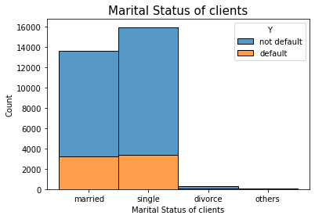

```python
#category_order = ['single','married','divorce','other']
#sns.catplot(x='MAR', data=df, kind='count', order=category_order)
sns.histplot(x='MAR', hue='Y', data=df, multiple='stack', hue_order=['not default', 'default'])

plt.xlabel('Marital Status of clients')
plt.ylabel('Count')
plt.title('Marital Status of clients',size = 15)

plt.show()
```

Most of defaulting clients are single or married.

#### EDUCATION

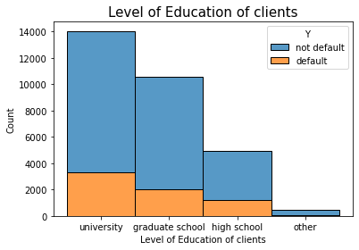

```python
#category_order = ['university','graduate school','high school','other']
#sns.catplot(x='EDU', data=df, kind='count', order=category_order)
sns.histplot(x='EDU', hue='Y', data=df, multiple='stack', hue_order=['not default', 'default'])

plt.xlabel('Level of Education of clients')
plt.ylabel('Count')
plt.title('Level of Education of clients',size = 15)

plt.show()
```

Most of our defaulting clients went to university.

##### SEX

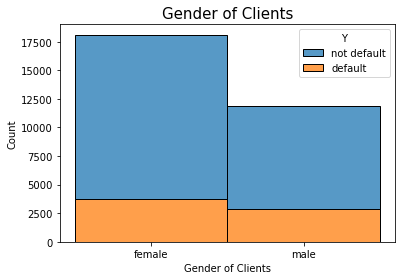

```python
#category_order = ['female','male']
#sns.catplot(x='SEX', data=df, kind='count', order=category_order)
sns.histplot(x='SEX', hue='Y', data=df, multiple='stack', hue_order=['not default', 'default'])

plt.xlabel('Gender of Clients')
plt.ylabel('Count')
plt.title('Gender of Clients',size = 15)

plt.show()
```

Most of our defaulting clients are female

#### AGE

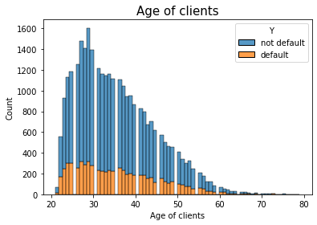

```python
#sns.catplot(x='AGE', data=df, kind='count', height= 5, aspect=5/1)
sns.histplot(x='AGE', hue='Y', data=df, multiple='stack', hue_order=['not default', 'default'])

plt.xlabel('Age of clients')
plt.ylabel('Count')
plt.title('Age of clients',size = 15)

plt.show()
```

Most of our defaulting clients are between 20 and 30 years old.

#### **Conclusion of Cat Variables** After a visual analysis of the categorical variable, most of defaulting clients are:

- Single
- University
- Female
- Between 20 and 30 years old

### Numerical Variable

#### LIMIT_BAL

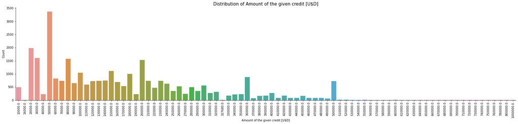

```python
sns.catplot(x='LIMIT_BAL', data=df, kind='count', height= 5, aspect=5/1)

plt.xlabel('Amount of the given credit [U$D]')
plt.ylabel('Count')
plt.title('Distribution of Amount of the given credit [U$D]',size = 15)

plt.xticks(rotation=90)
plt.show()
```

the most typical amount of given credit is $50.000

#### PAY history

```python
def draw_histograms(df, variables, n_rows, n_cols, n_bins, y_label = '', x_label = ''):
    fig=plt.figure(figsize=(15,6))
    for i, var_name in enumerate(variables):
        ax=fig.add_subplot(n_rows,n_cols,i+1)
        df[var_name].hist(bins=n_bins,ax=ax)
        ax.set_title(var_name)
        ax.set_xlabel(x_label)
        ax.set_ylabel(y_label)
    plt.figure()
    fig.tight_layout()  # Improves appearance a bit.
    plt.show()
```

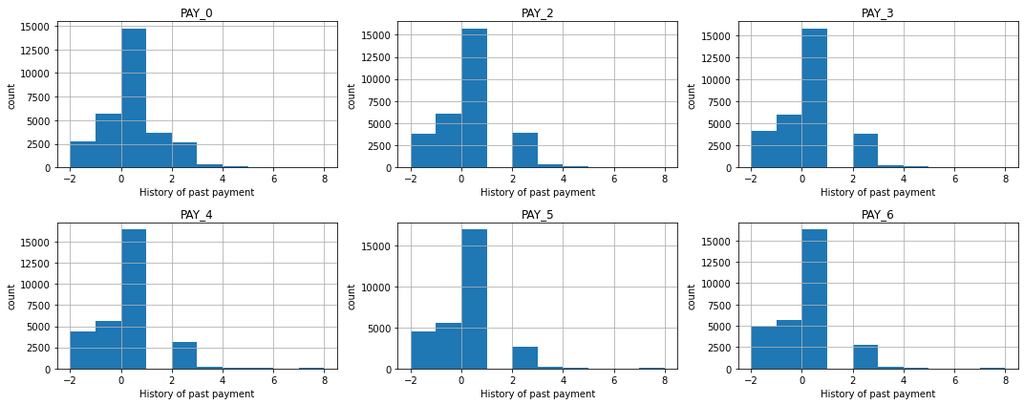

```python
pay_hist = df[['PAY_0', 'PAY_2', 'PAY_3', 'PAY_4', 'PAY_5', 'PAY_6']]

draw_histograms(pay_hist, pay_hist.columns,2,3,10,'count','History of past payment')
```

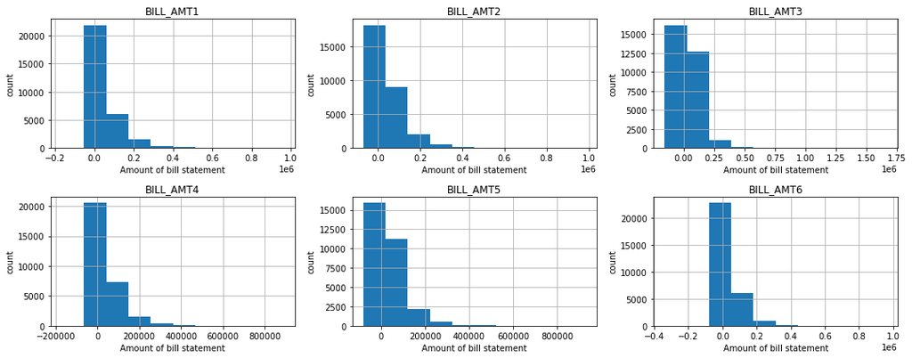

```python
amount_hist = df[['BILL_AMT1','BILL_AMT2','BILL_AMT3','BILL_AMT4','BILL_AMT5','BILL_AMT6']]

draw_histograms(amount_hist, amount_hist.columns,2,3,10,'count','Amount of bill statement')
```

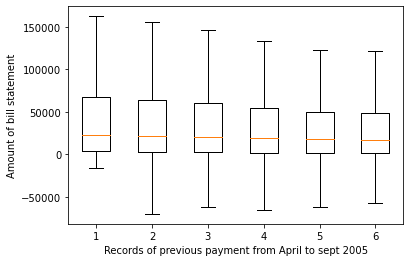

```python
fig, ax = plt.subplots()

ax.boxplot(amount_hist, showfliers=False) #Outliers turned off, just to be able to see beter the effect.

ax.set_ylabel('Amount of bill statement')
ax.set_xlabel('Records of previous payment from April to sept 2005')

plt.show()
```

#### PAY Amount

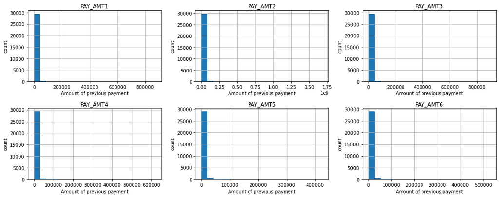

```python
bill_hist = df[['PAY_AMT1','PAY_AMT2','PAY_AMT3','PAY_AMT4','PAY_AMT5','PAY_AMT6']]

draw_histograms(bill_hist, bill_hist.columns,2,3,20,'count','Amount of previous payment')
```

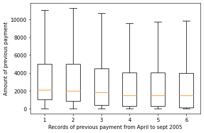

```python
fig, ax = plt.subplots()

ax.boxplot(bill_hist, showfliers=False) #Outliers turned off, just to be able to see beter the effect.

ax.set_ylabel('Amount of previous payment')
ax.set_xlabel('Records of previous payment from April to sept 2005')

plt.show()
```

#### BILL AMOUNT

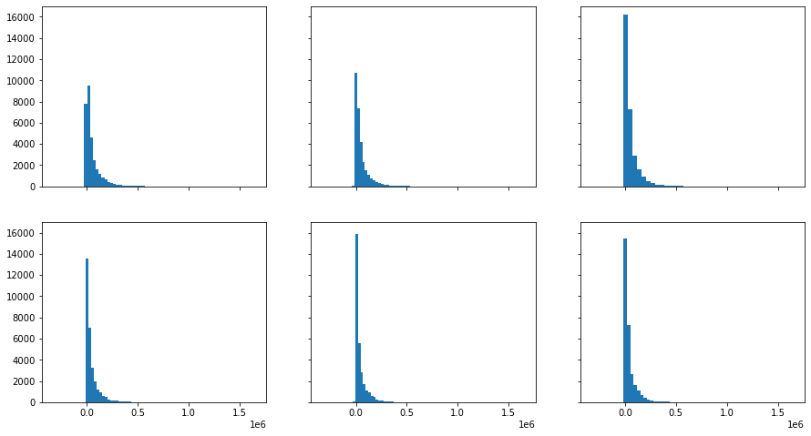

```python
fig, ax = plt.subplots(2,3, sharey=True, sharex=True)
ax[0,0].hist(df['BILL_AMT1'], bins=40)
ax[0,1].hist(df['BILL_AMT2'], bins=40)
ax[0,2].hist(df['BILL_AMT3'], bins=40)
ax[1,0].hist(df['BILL_AMT4'], bins=40)
ax[1,1].hist(df['BILL_AMT5'], bins=40)
ax[1,2].hist(df['BILL_AMT6'], bins=40)

fig.set_size_inches([15,8])
plt.show()
```

# 4.Feature Selection

Feature selection is a process where you automatically select those features in your data that contribute most to the prediction variable or output in which you are interested.

Having irrelevant features in your data can decrease the accuracy of many models, especially linear algorithms like linear and logistic regression.

Three benefits of performing feature selection before modeling your data are:

- **Reduces Overfitting**: Less redundant data means less opportunity to make decisions based on noise.
- **Improves Accuracy**: Less misleading data means modeling accuracy improves.
- **Reduces Training Time**: Less data means that algorithms train faster.

https://machinelearningmastery.com/feature-selection-machine-learning-python/

So first, recap the names of the columns. We'll use the dummies values.

```python
df_dummies.columns
```

```
Index(['ID', 'LIMIT_BAL', 'AGE', 'PAY_0', 'PAY_2', 'PAY_3', 'PAY_4', 'PAY_5',
       'PAY_6', 'BILL_AMT1', 'BILL_AMT2', 'BILL_AMT3', 'BILL_AMT4',
       'BILL_AMT5', 'BILL_AMT6', 'PAY_AMT1', 'PAY_AMT2', 'PAY_AMT3',
       'PAY_AMT4', 'PAY_AMT5', 'PAY_AMT6', 'SEX_female', 'SEX_male',
       'EDU_graduate school', 'EDU_high school', 'EDU_other', 'EDU_university',
       'MAR_divorce', 'MAR_married', 'MAR_others', 'MAR_single', 'Y_default',
       'Y_not default'],
      dtype='object')
```

The output is 'Y_Default', a categorical boolean variable, since our objective is to predict this.

And there are some categorical and numerical input variables.

Will divide the DF into Inputs and Outputs

```python
df_catOUT = df_dummies['Y_default']
df_IN = df_dummies[['SEX_female', 'SEX_male','EDU_graduate school', 'EDU_high school', 'EDU_other', 'EDU_university','MAR_divorce',
                        'MAR_married', 'MAR_others', 'MAR_single','LIMIT_BAL', 'AGE', 'PAY_0', 'PAY_2', 'PAY_3', 'PAY_4', 'PAY_5','PAY_6',
                        'BILL_AMT1', 'BILL_AMT2', 'BILL_AMT3', 'BILL_AMT4','BILL_AMT5','BILL_AMT6', 'PAY_AMT1', 'PAY_AMT2', 'PAY_AMT3','PAY_AMT4', 'PAY_AMT5', 'PAY_AMT6']]
```

**Univariate Selection**

Statistical tests can be used to select those features that have the strongest relationship with the output variable.

The scikit-learn library provides the SelectKBest class that can be used with a suite of different statistical tests to select a specific number of features.

Many different statistical test scan be used with this selection method. For example the **ANOVA F-value method is appropriate for numerical inputs and categorical data**.

This can be used via the f_classif() function. We will select the k best features using this method in the example below.

**The result is the scores for each attribute**.

```python
# Feature Selection with Univariate Statistical Tests    https://machinelearningmastery.com/feature-selection-machine-learning-python/
from numpy import set_printoptions
from sklearn.feature_selection import SelectKBest
from sklearn.feature_selection import f_classif
# load data
X = df_IN
Y = df_catOUT
# feature extraction
test = SelectKBest(score_func=f_classif, k=10)
fit = test.fit(X, Y)
# summarize scores
set_printoptions(precision=2)
#print(fit.scores_)
features = fit.transform(X)
# summarize selected features
#print(features[:,:])


# get the list of tuples from two lists. and merge them by using zip().
dic_scores = dict(zip(X.columns, fit.scores_))

# sort the dict in ascendent order by the value.
res = {key: val for key, val in sorted(dic_scores.items(), key = lambda ele: ele[1], reverse = True)}

#print the result
for k,v in res.items():
    print(str(k) + '\t' +  str(v))
```

```
PAY_0	3537.714969626687
PAY_2	2239.1691358465864
PAY_3	1757.466444026491
PAY_4	1476.8459673526688
PAY_5	1304.5911757099227
PAY_6	1085.4024851202532
LIMIT_BAL	724.0685392611682
PAY_AMT1	160.4038095819619
PAY_AMT2	103.2915242543617
PAY_AMT4	97.18800046896295
PAY_AMT3	95.21801088949987
PAY_AMT5	91.42980080214166
PAY_AMT6	85.08904532729818
EDU_graduate school	79.23962411752797
EDU_other	62.790643631080314
SEX_male	47.978854347638396
SEX_female	47.978854347626964
EDU_university	39.94646871105585
EDU_high school	31.53000697998699
MAR_single	28.150919379837536
MAR_married	26.617646975616573
BILL_AMT1	11.580531516293314
BILL_AMT2	6.044237892359451
BILL_AMT3	5.944387708457432
AGE	5.788555824708498
MAR_others	5.1944950671121655
BILL_AMT4	3.094745184781883
MAR_divorce	2.8625540601153006
BILL_AMT5	1.3710873966307768
BILL_AMT6	0.8658202918867746
```

## Feature selection, visual verification

### Plot the first 10 Numerical input variables

we can appreciate the difference in the distribution of the values.

```
PAY_XX
```

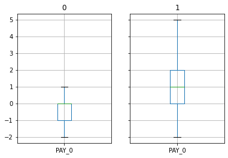

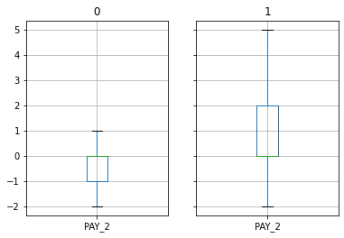

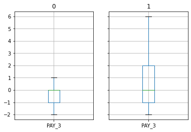

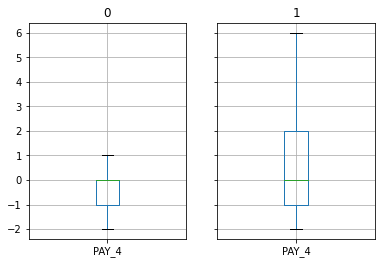

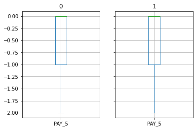

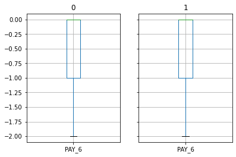

```
LIMIT_VAL
```

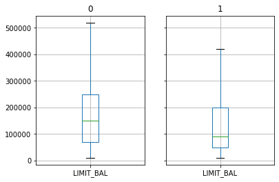

```
PAY_AMTXX
```

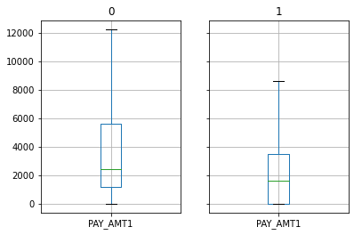

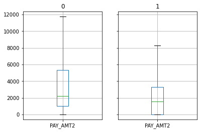

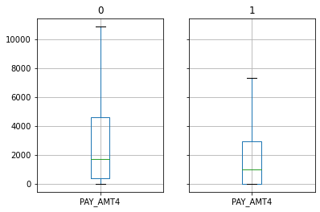

```python
# Improvement: change the way I'm defining the boxplot+groupby to be able to use the draw_histograms function



#fig, ax = plt.subplots()
print('PAY_XX')
ax = df_dummies.groupby("Y_default").boxplot(column="PAY_0",showfliers=False) #Outliers turned off, just to be able to see beter the effect.
ax = df_dummies.groupby("Y_default").boxplot(column="PAY_2",showfliers=False)
ax = df_dummies.groupby("Y_default").boxplot(column="PAY_3",showfliers=False)
ax = df_dummies.groupby("Y_default").boxplot(column="PAY_4",showfliers=False)
ax = df_dummies.groupby("Y_default").boxplot(column="PAY_5",showfliers=False)
ax = df_dummies.groupby("Y_default").boxplot(column="PAY_6",showfliers=False)
plt.show()


print('LIMIT_VAL')
ax = df_dummies.groupby("Y_default").boxplot(column="LIMIT_BAL",showfliers=False)
plt.show()

print('PAY_AMTXX')
ax = df_dummies.groupby("Y_default").boxplot(column="PAY_AMT1",showfliers=False)
ax = df_dummies.groupby("Y_default").boxplot(column="PAY_AMT2",showfliers=False)
ax = df_dummies.groupby("Y_default").boxplot(column="PAY_AMT4",showfliers=False)
plt.show()
```

### and just to contrast, some of the variables with less prediction power

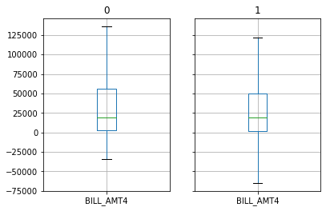

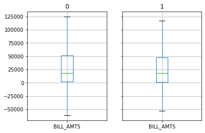

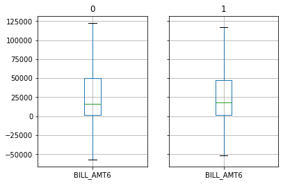

```python
ax = df_dummies.groupby("Y_default").boxplot(column="BILL_AMT4",showfliers=False)
ax = df_dummies.groupby("Y_default").boxplot(column="BILL_AMT5",showfliers=False)
ax = df_dummies.groupby("Y_default").boxplot(column="BILL_AMT6",showfliers=False)

plt.show()
```

## Feature Selection Conclusion

Feature Selection Conclusion: the most useful input variables are: PAY_0, PAY_2, PAY_3, PAY_4, PAY_5, PAY_6 and LIMIT_BAL

# Draft Zone

## an interesting iteration over heatmaps..

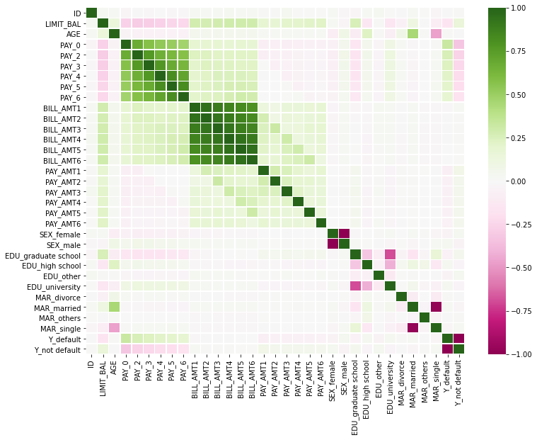

```python
f, ax = plt.subplots(figsize=(12,9))

sns.heatmap(df_dummies.corr(), cmap="PiYG", linewidths=.5, center=0)
```

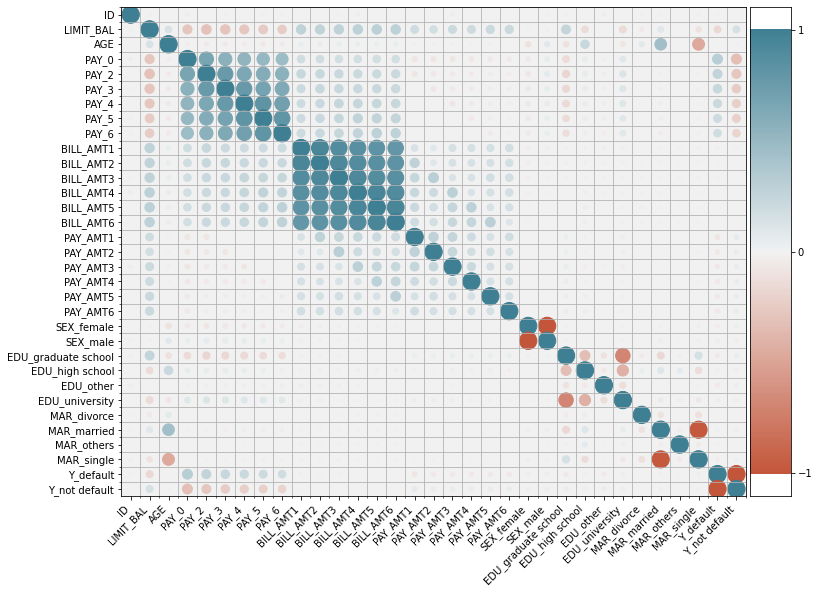

```python
# corrplot from heatmapz https://pypi.org/project/heatmapz/
from heatmap import corrplot

f, ax = plt.subplots(figsize=(12,9))
ax = corrplot(df_dummies.corr(), size_scale=300, marker='o')
plt.show()
```

## Another kind of feature extraction

```python
# Feature Extraction with RFE
from sklearn.feature_selection import RFE
from sklearn.linear_model import LogisticRegression

# feature extraction
model = LogisticRegression(solver='lbfgs')
rfe = RFE(model, 8)
fit = rfe.fit(X, Y)
print("Num Features: %d" % fit.n_features_)
print("Selected Features: %s" % fit.support_)
print("Feature Ranking: %s" % fit.ranking_)
```

[output not shown]

[output cut: 75 more lines]

[output not shown]

```
Num Features: 8
Selected Features: [False False False False False False False False False False False  True
  True  True  True  True  True  True False False False False False False
  True False False False False False]
Feature Ranking: [14 16 17 18 20 15 22 19 23 13  8  1  1  1  1  1  1  1  6  9  5 21  7 12
  1  2  4  3 11 10]
```